# S&DS 220 Chapter 1 code examples

Braeden Cullen

2024-01-16

# 1 Data in R

This document contains code examples of the topics contained in Chapter 1 of [*Probability, Statistics, and Data: A fresh approach using R*](https://mathstat.slu.edu/~speegle/_book/preface.html) by Darrin Speegle and Bryan Clair.

For each bullet point in the sections below, add a code chunk with code examples. To add a code chunk, go to “Code -> Insert Chunk” or use the shortcut `option` + `command` + `i`.

```r
2 + 2
```

```
## [1] 4
```

## 1.1 Arithmetic and variable assignment

- operations: `+`, `-`, `*`, `/`, also `^`, `**`, `%%`
- exponentials and logarithms: `exp`, `log`
- storing variables `<-` and the `str` function
- comments `#`

## 1.2 Help

- help with `?` and the “Help” tab in RStudio

## 1.3 Vectors

- don’t forget that R is 1-indexed, unlike most other languages like python
- the combine function `c -> used to create vectors, since we are combining entries

```r
c(1:4, -10:-14) # combines 1 to 4 and -10 to -14
```

```
## [1]   1   2   3   4 -10 -11 -12 -13 -14
```

- the `:` operator, makes a vector itself but can also be used c(1:10) in the same manner to create a vector

```r
3:10
```

```
## [1]  3  4  5  6  7  8  9 10
```

- the `rep` function with arguments `times`, `length.out`, or `each`

```r
rep(c(1:4, -10:-14), times = 3)
```

```
##  [1]   1   2   3   4 -10 -11 -12 -13 -14   1   2   3   4 -10 -11 -12 -13 -14   1
## [20]   2   3   4 -10 -11 -12 -13 -14
```

```r
rep(pi, times =)
```

```
## [1] 3.141593
```

- example with `c` and `rep`

```r
v1 <- rep(c("abe", "bello"), each = 5)
v2 <- rep(c("abe", "bello"), times = 5)
v1
```

```
##  [1] "abe"   "abe"   "abe"   "abe"   "abe"   "bello" "bello" "bello" "bello"
## [10] "bello"
```

```r
v2
```

```
##  [1] "abe"   "bello" "abe"   "bello" "abe"   "bello" "abe"   "bello" "abe"
## [10] "bello"
```

```r
v3 <- rep(1:52, length.out = 100)
v3
```

```
##   [1]  1  2  3  4  5  6  7  8  9 10 11 12 13 14 15 16 17 18 19 20 21 22 23 24 25
##  [26] 26 27 28 29 30 31 32 33 34 35 36 37 38 39 40 41 42 43 44 45 46 47 48 49 50
##  [51] 51 52  1  2  3  4  5  6  7  8  9 10 11 12 13 14 15 16 17 18 19 20 21 22 23
##  [76] 24 25 26 27 28 29 30 31 32 33 34 35 36 37 38 39 40 41 42 43 44 45 46 47 48
```

```r
v4 <- rep(1:50, length.out = 100)
v4
```

```
##   [1]  1  2  3  4  5  6  7  8  9 10 11 12 13 14 15 16 17 18 19 20 21 22 23 24 25
##  [26] 26 27 28 29 30 31 32 33 34 35 36 37 38 39 40 41 42 43 44 45 46 47 48 49 50
##  [51]  1  2  3  4  5  6  7  8  9 10 11 12 13 14 15 16 17 18 19 20 21 22 23 24 25
##  [76] 26 27 28 29 30 31 32 33 34 35 36 37 38 39 40 41 42 43 44 45 46 47 48 49 50
```

- `seq` function with arguments `from`, `to` and `by`, or `length.out`

```r
seq(from = 0, to = 100, by = 1)
```

```
##   [1]   0   1   2   3   4   5   6   7   8   9  10  11  12  13  14  15  16  17
##  [19]  18  19  20  21  22  23  24  25  26  27  28  29  30  31  32  33  34  35
##  [37]  36  37  38  39  40  41  42  43  44  45  46  47  48  49  50  51  52  53
##  [55]  54  55  56  57  58  59  60  61  62  63  64  65  66  67  68  69  70  71
##  [73]  72  73  74  75  76  77  78  79  80  81  82  83  84  85  86  87  88  89
##  [91]  90  91  92  93  94  95  96  97  98  99 100
```

```r
seq(from = 0, to = 1, by = 0.01)
```

```
##   [1] 0.00 0.01 0.02 0.03 0.04 0.05 0.06 0.07 0.08 0.09 0.10 0.11 0.12 0.13 0.14
##  [16] 0.15 0.16 0.17 0.18 0.19 0.20 0.21 0.22 0.23 0.24 0.25 0.26 0.27 0.28 0.29
##  [31] 0.30 0.31 0.32 0.33 0.34 0.35 0.36 0.37 0.38 0.39 0.40 0.41 0.42 0.43 0.44
##  [46] 0.45 0.46 0.47 0.48 0.49 0.50 0.51 0.52 0.53 0.54 0.55 0.56 0.57 0.58 0.59
##  [61] 0.60 0.61 0.62 0.63 0.64 0.65 0.66 0.67 0.68 0.69 0.70 0.71 0.72 0.73 0.74
##  [76] 0.75 0.76 0.77 0.78 0.79 0.80 0.81 0.82 0.83 0.84 0.85 0.86 0.87 0.88 0.89
##  [91] 0.90 0.91 0.92 0.93 0.94 0.95 0.96 0.97 0.98 0.99 1.00
```

```r
seq(from = 0, to = 1, length.out = 11)
```

```
##  [1] 0.0 0.1 0.2 0.3 0.4 0.5 0.6 0.7 0.8 0.9 1.0
```

- operations on vectors

```r
x <- c(1, 2, 3, 4, 5)
2*x
```

```
## [1]  2  4  6  8 10
```

```r
x+2
```

```
## [1] 3 4 5 6 7
```

```r
x^2
```

```
## [1]  1  4  9 16 25
```

- `sum`, `mean`, `max`, `min`

```r
sum(x)
```

```
## [1] 15
```

```r
mean(x)
```

```
## [1] 3
```

```r
max(x)
```

```
## [1] 5
```

```r
min(x)
```

```
## [1] 1
```

- basic scatterplot `plot(x, y)`

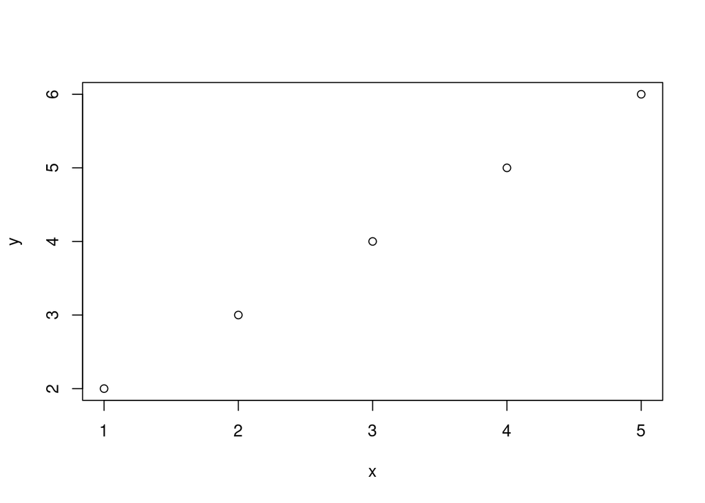

```r
y <- c(2, 3, 4, 5, 6)
plot(x, y)
```

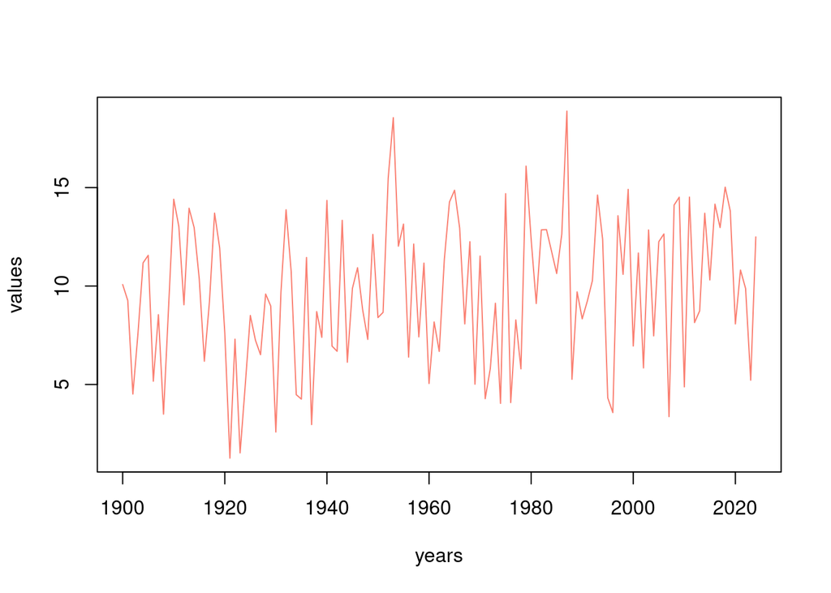

```r
years <- 1900:2024
set.seed(10)
values <- rnorm(n = length(years), mean = 10, sd = 4)
plot(x = years, y = values, col = "salmon", type = "l")
```

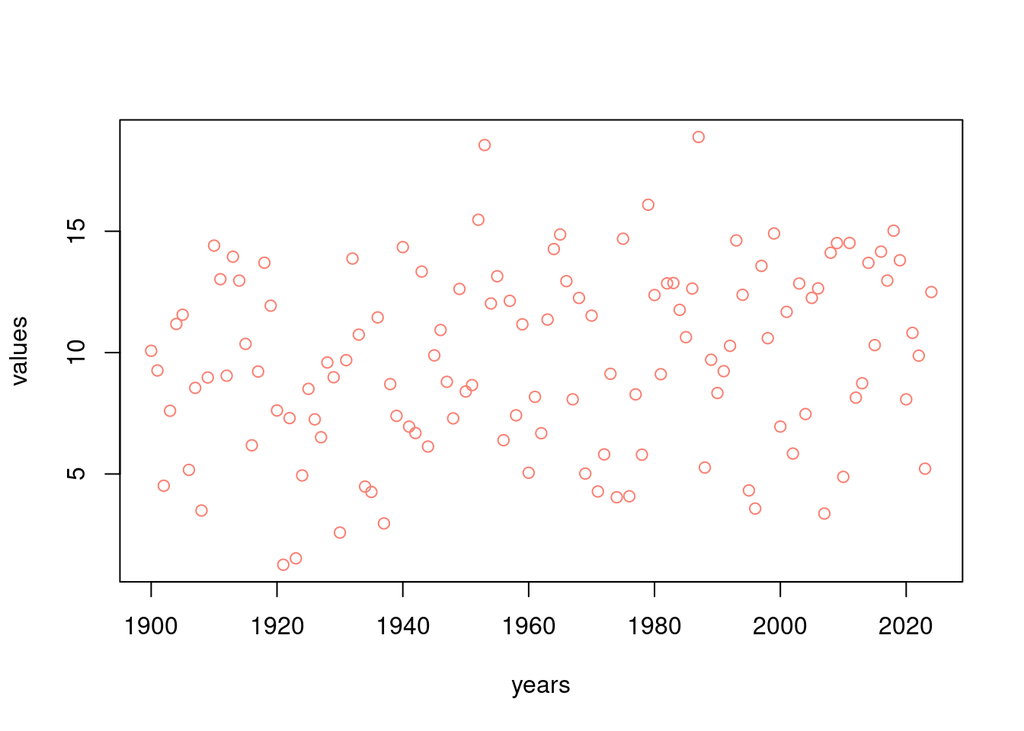

```r
plot(x = years, y = values, col = "salmon")
```

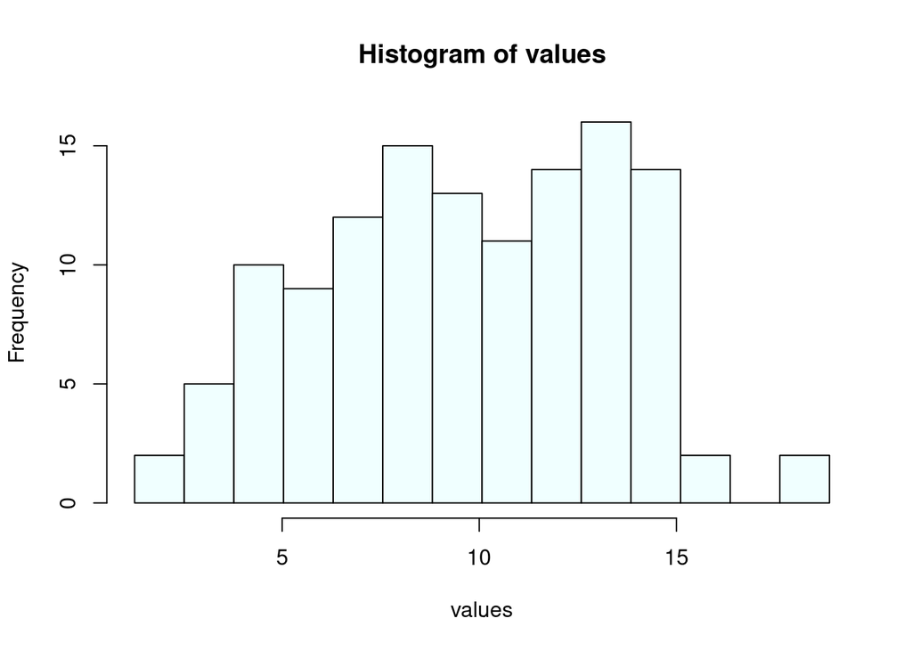

```r
hist(values, col="azure", breaks = seq(from = min(values),
                                       to = max(values),
                                       length.out = 15))
```

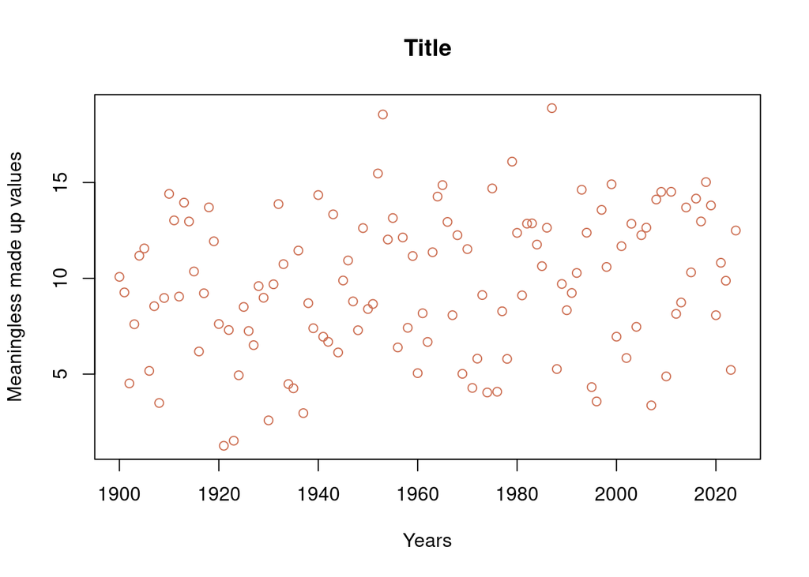

```r
plot(x = years,
     y = values,
     col = "salmon3",
     xlab = "Years",
     ylab = "Meaningless made up values",
     main = "Title")
```

## 1.4 Indexing vectors

- indexing with numbers

```r
values[1:5]
```

```
## [1] 10.074985  9.262990  4.514678  7.603329 11.178181
```

```r
values[10]
```

```
## [1] 8.974086
```

```r
values[seq(from = 1, to = length(values), by = 2)]
```

```
##  [1] 10.074985  4.514678 11.178181  5.167695  3.493309 14.407118  9.047066
##  [8] 12.965561  6.180225 13.702085  7.614757  7.300536  4.939208  7.249778
## [15]  9.592956  2.585038 13.874265  4.480226 11.448349  8.701824 14.346206
## [22]  6.685350  6.129392 10.930101  7.289542  8.397450 15.471816 12.023277
## [29]  6.391152  7.416423  5.049622  6.678709 14.265506 12.942763 12.250979
## [36] 11.523689  5.806218  4.040255  4.080692  5.793445 12.371312 12.851577
## [43] 11.760967 12.639057  5.264220  8.334581 10.278179 12.379829  3.573291
## [50] 10.592672  6.952783  5.840227  7.467148 12.643947 14.112672  4.879382
## [57]  8.143462 13.697173 14.159694 15.022179  8.074538  9.873041 12.494725
```

- indexing with logicals

```r
which.max(values) # location of max val
```

```
## [1] 88
```

```r
which.min(values) # location of min val
```

```
## [1] 22
```

- indexing with comparisons: `==`, `!=`, `>`, `<`, `>=`, `<=`

```r
values[values > 15 | values < 5]
```

```
##  [1]  4.514678  3.493309  1.258853  1.523755  4.939208  2.585038  4.480226
##  [8]  4.257943  2.963653 15.471816 18.551068  4.278291  4.040255  4.080692
## [15] 16.090345 18.882079  4.321420  3.573291  3.367797  4.879382 15.022179
```

```r
values > 10
```

```
##   [1]  TRUE FALSE FALSE FALSE  TRUE  TRUE FALSE FALSE FALSE FALSE  TRUE  TRUE
##  [13] FALSE  TRUE  TRUE  TRUE FALSE FALSE  TRUE  TRUE FALSE FALSE FALSE FALSE
##  [25] FALSE FALSE FALSE FALSE FALSE FALSE FALSE FALSE  TRUE  TRUE FALSE FALSE
##  [37]  TRUE FALSE FALSE FALSE  TRUE FALSE FALSE  TRUE FALSE FALSE  TRUE FALSE
##  [49] FALSE  TRUE FALSE FALSE  TRUE  TRUE  TRUE  TRUE FALSE  TRUE FALSE  TRUE
##  [61] FALSE FALSE FALSE  TRUE  TRUE  TRUE  TRUE FALSE  TRUE FALSE  TRUE FALSE
##  [73] FALSE FALSE FALSE  TRUE FALSE FALSE FALSE  TRUE  TRUE FALSE  TRUE  TRUE
##  [85]  TRUE  TRUE  TRUE  TRUE FALSE FALSE FALSE FALSE  TRUE  TRUE  TRUE FALSE
##  [97] FALSE  TRUE  TRUE  TRUE FALSE  TRUE FALSE  TRUE FALSE  TRUE  TRUE FALSE
## [109]  TRUE  TRUE FALSE  TRUE FALSE FALSE  TRUE  TRUE  TRUE  TRUE  TRUE  TRUE
## [121] FALSE  TRUE FALSE FALSE  TRUE
```

```r
values[!(values > 5)] # will give you all values !(>5)
```

```
##  [1] 4.514678 3.493309 1.258853 1.523755 4.939208 2.585038 4.480226 4.257943
##  [9] 2.963653 4.278291 4.040255 4.080692 4.321420 3.573291 3.367797 4.879382
```

- subset with `%in%`
- built in data sets: `rivers`, `discoveries`
- `head`, `sort`, `table`

```r
head(rivers, n = 10)
```

```
##  [1]  735  320  325  392  524  450 1459  135  465  600
```

```r
head(sort(rivers), n = 10)
```

```
##  [1] 135 202 210 210 215 217 230 230 233 237
```

```r
head(sort(rivers, decreasing = TRUE), n=10)
```

```
##  [1] 3710 2533 2348 2315 1885 1770 1459 1450 1306 1270
```

```r
head(sort(rivers, decreasing = FALSE, n=10))
```

```
## [1] 135 202 210 210 215 217
```

## 1.5 Data types

- numeric
- integer
- character
- logical
- factor
- complex
- raw
- missing values: `NA`, `na.rm = TRUE`
- note, NA is not true or false ! it is unknown

```r
exam_scores <- c(92, 70, 30, 42, 99, 88, 72, NA, 13)
exam_scores > 75
```

```
## [1]  TRUE FALSE FALSE FALSE  TRUE  TRUE FALSE    NA FALSE
```

```r
# mean(exam_scores) -> returns NA since can't take mean of vector which has NA
length(exam_scores)
```

```
## [1] 9
```

```r
mean(exam_scores, na.rm = TRUE)
```

```
## [1] 63.25
```

## 1.6 Data frames

- examples: `trees`, `mtcars`, `airquality`

```r
head(airquality)
```

```
##   Ozone Solar.R Wind Temp Month Day
## 1    41     190  7.4   67     5   1
## 2    36     118  8.0   72     5   2
## 3    12     149 12.6   74     5   3
## 4    18     313 11.5   62     5   4
## 5    NA      NA 14.3   56     5   5
## 6    28      NA 14.9   66     5   6
```

```r
head(trees)
```

```
##   Girth Height Volume
## 1   8.3     70   10.3
## 2   8.6     65   10.3
## 3   8.8     63   10.2
## 4  10.5     72   16.4
## 5  10.7     81   18.8
## 6  10.8     83   19.7
```

```r
head(mtcars)
```

```
##                    mpg cyl disp  hp drat    wt  qsec vs am gear carb
## Mazda RX4         21.0   6  160 110 3.90 2.620 16.46  0  1    4    4
## Mazda RX4 Wag     21.0   6  160 110 3.90 2.875 17.02  0  1    4    4
## Datsun 710        22.8   4  108  93 3.85 2.320 18.61  1  1    4    1
## Hornet 4 Drive    21.4   6  258 110 3.08 3.215 19.44  1  0    3    1
## Hornet Sportabout 18.7   8  360 175 3.15 3.440 17.02  0  0    3    2
## Valiant           18.1   6  225 105 2.76 3.460 20.22  1  0    3    1
```

```r
tail (airquality, n = 20)
```

```
##     Ozone Solar.R Wind Temp Month Day
## 134    44     236 14.9   81     9  11
## 135    21     259 15.5   76     9  12
## 136    28     238  6.3   77     9  13
## 137     9      24 10.9   71     9  14
## 138    13     112 11.5   71     9  15
## 139    46     237  6.9   78     9  16
## 140    18     224 13.8   67     9  17
## 141    13      27 10.3   76     9  18
## 142    24     238 10.3   68     9  19
## 143    16     201  8.0   82     9  20
## 144    13     238 12.6   64     9  21
## 145    23      14  9.2   71     9  22
## 146    36     139 10.3   81     9  23
## 147     7      49 10.3   69     9  24
## 148    14      20 16.6   63     9  25
## 149    30     193  6.9   70     9  26
## 150    NA     145 13.2   77     9  27
## 151    14     191 14.3   75     9  28
## 152    18     131  8.0   76     9  29
## 153    20     223 11.5   68     9  30
```

```r
dim(airquality) # num rows num cols
```

```
## [1] 153   6
```

```r
str(airquality)
```

```
## 'data.frame':    153 obs. of  6 variables:
##  $ Ozone  : int  41 36 12 18 NA 28 23 19 8 NA ...
##  $ Solar.R: int  190 118 149 313 NA NA 299 99 19 194 ...
##  $ Wind   : num  7.4 8 12.6 11.5 14.3 14.9 8.6 13.8 20.1 8.6 ...
##  $ Temp   : int  67 72 74 62 56 66 65 59 61 69 ...
##  $ Month  : int  5 5 5 5 5 5 5 5 5 5 ...
##  $ Day    : int  1 2 3 4 5 6 7 8 9 10 ...
```

```r
summary(airquality)
```

```
##      Ozone           Solar.R           Wind             Temp
##  Min.   :  1.00   Min.   :  7.0   Min.   : 1.700   Min.   :56.00
##  1st Qu.: 18.00   1st Qu.:115.8   1st Qu.: 7.400   1st Qu.:72.00
##  Median : 31.50   Median :205.0   Median : 9.700   Median :79.00
##  Mean   : 42.13   Mean   :185.9   Mean   : 9.958   Mean   :77.88
##  3rd Qu.: 63.25   3rd Qu.:258.8   3rd Qu.:11.500   3rd Qu.:85.00
##  Max.   :168.00   Max.   :334.0   Max.   :20.700   Max.   :97.00
##  NA's   :37       NA's   :7
##      Month            Day
##  Min.   :5.000   Min.   : 1.0
##  1st Qu.:6.000   1st Qu.: 8.0
##  Median :7.000   Median :16.0
##  Mean   :6.993   Mean   :15.8
##  3rd Qu.:8.000   3rd Qu.:23.0
##  Max.   :9.000   Max.   :31.0
##
```

```r
airquality_mod <- airquality
airquality_mod$Month <- factor(airquality_mod$Month, ordered = TRUE)
str(airquality_mod)
```

```
## 'data.frame':    153 obs. of  6 variables:
##  $ Ozone  : int  41 36 12 18 NA 28 23 19 8 NA ...
##  $ Solar.R: int  190 118 149 313 NA NA 299 99 19 194 ...
##  $ Wind   : num  7.4 8 12.6 11.5 14.3 14.9 8.6 13.8 20.1 8.6 ...
##  $ Temp   : int  67 72 74 62 56 66 65 59 61 69 ...
##  $ Month  : Ord.factor w/ 5 levels "5"<"6"<"7"<"8"<..: 1 1 1 1 1 1 1 1 1 1 ...
##  $ Day    : int  1 2 3 4 5 6 7 8 9 10 ...
```

```r
summary(airquality_mod)
```

```
##      Ozone           Solar.R           Wind             Temp       Month
##  Min.   :  1.00   Min.   :  7.0   Min.   : 1.700   Min.   :56.00   5:31
##  1st Qu.: 18.00   1st Qu.:115.8   1st Qu.: 7.400   1st Qu.:72.00   6:30
##  Median : 31.50   Median :205.0   Median : 9.700   Median :79.00   7:31
##  Mean   : 42.13   Mean   :185.9   Mean   : 9.958   Mean   :77.88   8:31
##  3rd Qu.: 63.25   3rd Qu.:258.8   3rd Qu.:11.500   3rd Qu.:85.00   9:30
##  Max.   :168.00   Max.   :334.0   Max.   :20.700   Max.   :97.00
##  NA's   :37       NA's   :7
##       Day
##  Min.   : 1.0
##  1st Qu.: 8.0
##  Median :16.0
##  Mean   :15.8
##  3rd Qu.:23.0
##  Max.   :31.0
##
```

```r
airquality_mod[airquality_mod$Ozone > 20 & is.na(airquality_mod$Ozone), ]
```

```
##       Ozone Solar.R Wind Temp Month Day
## NA       NA      NA   NA   NA  <NA>  NA
## NA.1     NA      NA   NA   NA  <NA>  NA
## NA.2     NA      NA   NA   NA  <NA>  NA
## NA.3     NA      NA   NA   NA  <NA>  NA
## NA.4     NA      NA   NA   NA  <NA>  NA
## NA.5     NA      NA   NA   NA  <NA>  NA
## NA.6     NA      NA   NA   NA  <NA>  NA
## NA.7     NA      NA   NA   NA  <NA>  NA
## NA.8     NA      NA   NA   NA  <NA>  NA
## NA.9     NA      NA   NA   NA  <NA>  NA
## NA.10    NA      NA   NA   NA  <NA>  NA
## NA.11    NA      NA   NA   NA  <NA>  NA
## NA.12    NA      NA   NA   NA  <NA>  NA
## NA.13    NA      NA   NA   NA  <NA>  NA
## NA.14    NA      NA   NA   NA  <NA>  NA
## NA.15    NA      NA   NA   NA  <NA>  NA
## NA.16    NA      NA   NA   NA  <NA>  NA
## NA.17    NA      NA   NA   NA  <NA>  NA
## NA.18    NA      NA   NA   NA  <NA>  NA
## NA.19    NA      NA   NA   NA  <NA>  NA
## NA.20    NA      NA   NA   NA  <NA>  NA
## NA.21    NA      NA   NA   NA  <NA>  NA
## NA.22    NA      NA   NA   NA  <NA>  NA
## NA.23    NA      NA   NA   NA  <NA>  NA
## NA.24    NA      NA   NA   NA  <NA>  NA
## NA.25    NA      NA   NA   NA  <NA>  NA
## NA.26    NA      NA   NA   NA  <NA>  NA
## NA.27    NA      NA   NA   NA  <NA>  NA
## NA.28    NA      NA   NA   NA  <NA>  NA
## NA.29    NA      NA   NA   NA  <NA>  NA
## NA.30    NA      NA   NA   NA  <NA>  NA
## NA.31    NA      NA   NA   NA  <NA>  NA
## NA.32    NA      NA   NA   NA  <NA>  NA
## NA.33    NA      NA   NA   NA  <NA>  NA
## NA.34    NA      NA   NA   NA  <NA>  NA
## NA.35    NA      NA   NA   NA  <NA>  NA
## NA.36    NA      NA   NA   NA  <NA>  NA
```

```r
airquality_mod[1:5, c("Wind", "Day")]
```

```
##   Wind Day
## 1  7.4   1
## 2  8.0   2
## 3 12.6   3
## 4 11.5   4
## 5 14.3   5
```

```r
my_squaring_func <- function(x) {
  x^2
}
```

- `str`, `head`, `summary`
- subsetting `[<rows> , <columns>]`
- rows/columns by numeric vectors, logicals
- columns by character vector with column names
- getting columns with `<dataset name>$<column name>`
- `which.max`, `which.min`

## 1.7 Reading data from files

- `read.csv`
- working directory: `getwd()`, `setwd()`

## 1.8 Packages

- `install.packages("<package name>")`
- `library(<package name>)`